# Ford GoBike Dataset Exploration

## by Mingmin Wang

> This data set includes information about individual rides made in a bike-sharing system covering the greater San Francisco Bay area.

## Dataset Overview

After data wrangling, the fbike dataframe has 174952 rows and 19 columns; each row is a record of a Ford GoBike renting occurance. Each column shows the information of that occurance, including duration, start and end time, start and end location, bike ID, station ID, user's type, birth year, and gender, etc.

## Investigation Overview

The main feature in this dataset is distribution of the usage of the Ford GoBike among different features (columns). I am interested in finding out what feature affects the usage of the bike sharing system, and to what extent. Here are the questions I want to answer:

1. During what time of the day do we have the most rides?
2. What is the distribution of distance or duration are people using Ford GoBike for?
3. Are men using the bike more than women?
4. What age groups are using Ford GoBike most frequently?

## Univariate Exploration - distribution of ride duration

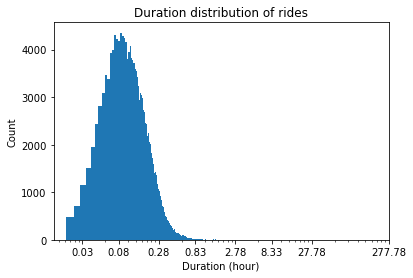

```python
# Distribution of the ride duration
plt.hist(data=fbike_clean.query('distance<10'), x='duration_sec', bins=5000);
plt.xscale('log') # log transformation on the duration time (seconds)
ticks=[100, 300, 1000, 3000, 10000, 30000, 100000, 1000000];
labels = ['{:.2f}'.format(v) for v in np.array(ticks)/3600];
plt.xticks(ticks, labels);

plt.xlabel('Duration (hour)');
plt.ylabel('Count');
plt.title('Duration distribution of rides');
```

> According to the histogram of duration above, most rides last 0.03 to 0.28 hours, while very few of them last more than 1 hour. This suggests that most users are using the bike for short trips.

## Univariate Exploration - distribution of ride distance

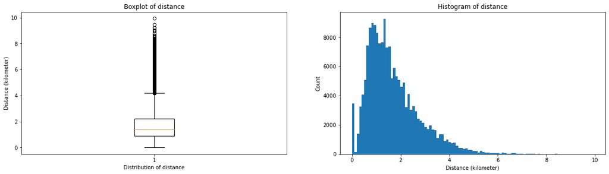

```python
# Distance of bike rides
plt.figure(figsize = [20, 5]);
plt.subplot(1, 2, 1) ;
# removing distance larger than 69 km (outliers);
plt.boxplot(data=fbike_clean.query('distance < 10'), x='distance');
plt.xlabel('Distribution of distance');
plt.ylabel('Distance (kilometer)');
plt.title('Boxplot of distance');

plt.subplot(1, 2, 2) ;
plt.hist(data=fbike_clean.query('distance < 10'), x='distance', bins=100);
plt.xlabel('Distance (kilometer)');
plt.ylabel('Count');
plt.title('Histogram of distance');
```

> The bosplot above shows the median of distance is about 1.5 kilometers. The histogram above shows a right skewed distribution, with most distances distributed between 0 to 4 kilimeters. Very few of the rides last longer than 6 kilometers.

## Univariate Exploration - distribution of ride start time

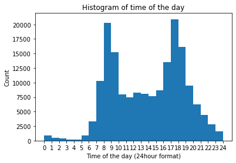

```python
# Time of the day when bike rides happened
bin_edges = np.arange(0, 24+1, 1);

plt.hist(data=fbike_clean, x='hour', bins=bin_edges);
plt.xlabel('Time of the day (24hour format)');
plt.ylabel('Count');
plt.title('Histogram of time of the day');
plt.xticks(np.arange(0, 24+1, 1));
```

> The distribution of time of the day when the bike usage starts is interesting. It clearly shows two modes: one during the morning rush hour between 7 to 10 am, another is during the evening rush hour between 5pm to 8pm.

## Univariate Exploration - distribution of user's age

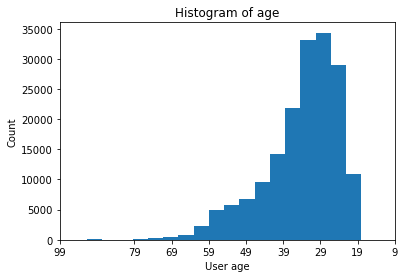

```python
# user's age distribution
plt.hist(data=fbike_clean, x='member_birth_year', bins=30);
plt.xlabel('User age');
plt.ylabel('Count');
plt.title('Histogram of age');


ticks=[1920, 1940, 1950, 1960, 1970, 1980, 1990, 2000, 2010];
labels = ['{}'.format(v) for v in 2019-np.array(ticks)];
plt.xticks(ticks, labels); # relabel the x axis with ages in stead of birth year
plt.xlim([1920, 2010]); # excluding ages older than 100, whihc could be errors in dataset
```

> The age distribution among the users shows a left skewed distribution, with 20 to 40 years old being the most active group of people who use the bike.

## Univariate Exploration - distribution of gender, user type

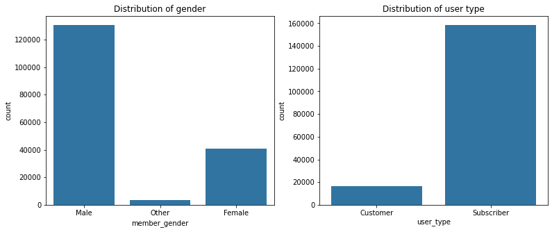

```python
# Distribution of gender
plt.figure(figsize=[20,5]);
plt.subplot(1,3,1);
base_color=sb.color_palette()[0];
sb.countplot(data=fbike_clean, x='member_gender', color=base_color);
plt.title('Distribution of gender');

plt.subplot(1,3,2);
sb.countplot(data=fbike_clean, x='user_type', color=base_color);
plt.title('Distribution of user type');
```

> The distibution of gender clear shows men are using the bike almost three times more frequently compared to women. Most of the users are subscribers.

### Discuss the distribution(s) of your variable(s) of interest. Were there any unusual points? Did you need to perform any transformations?

> The distribution of duration is close to normal distribution between 0 to 0.8 hours, but it has some outliers with duration longer than 1 hour. I performed log transformation on the duration data, and relabeled the x axis so it shows the duration in hours. The distribution of the start time of the rides are as expected, with two modes corresponding to morning rush and evening rush of the day.

### Of the features you investigated, were there any unusual distributions? Did you perform any operations on the data to tidy, adjust, or change the form of the data? If so, why did you do this?

> I did calculate the ages from the birth year and relabeled the x axis to show ages. The distribution of age of the users show some very large ages such as 120 years old. So I set the x axis limits to show only ages smaller than 99 years old.

## Bivariate Exploration - relationship between distance and duration

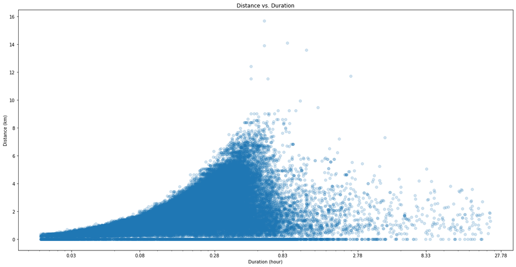

```python
plt.figure(figsize=[20,10])
plt.scatter(data=fbike_clean[fbike_clean.distance<60], x='duration_sec', y='distance', alpha=0.2)
plt.xscale('log')
ticks=[100, 300, 1000, 3000, 10000, 30000, 100000];
labels = ['{:.2f}'.format(v) for v in np.array(ticks)/3600];
plt.xticks(ticks, labels);

plt.xlabel('Duration (hour)')
plt.ylabel('Distance (km)')
plt.title('Distance vs. Duration');
```

> There are some tend that distance increases with duration, but this is not obvious. There are lots of overlapting of the data points.

## Bivariate Exploration - relationship between distance and age

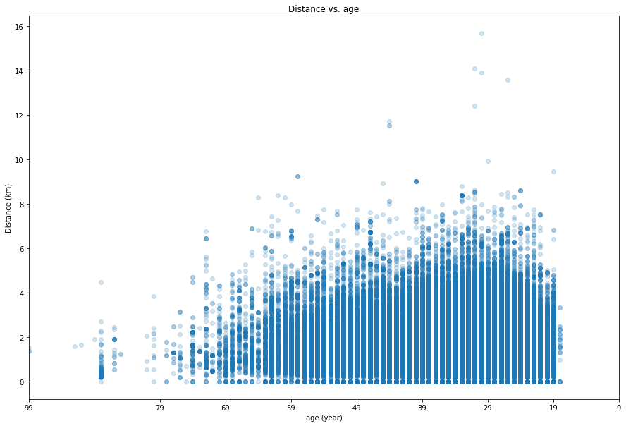

```python
plt.figure(figsize=[15,10])

plt.scatter(data=fbike_clean[fbike_clean.distance<60], x='member_birth_year', y='distance', alpha=0.2)
ticks=[1920, 1940, 1950, 1960, 1970, 1980, 1990, 2000, 2010];
labels = ['{}'.format(v) for v in 2019-np.array(ticks)]
plt.xticks(ticks, labels) # relabel the x axis with ages in stead of birth year
plt.xlim([1920, 2010]) # excluding ages older than 100, whihc could be errors in dataset

plt.xlabel('age (year)')
plt.ylabel('Distance (km)');
plt.title('Distance vs. age');
```

> The plot above shows a slight trend that young people tend to travel longer distance than older people, although there are lots of data point overlapping.

### Talk about some of the relationships you observed in this part of the investigation. How did the feature(s) of interest vary with other features in the dataset?

> I plotted the scatter plot of distance vs. duration and the plot of distance vs. age. It is not what I expected. I expected longer distance should have longer duration, and younger people should travel longder distance. It turns out the the relation between distance and duration are complicated, only slightly suggesting that longer duration means longer distance. This is similar with the distance-age plot.

## Multivariate Exploration - relationship between duration and age for different genders

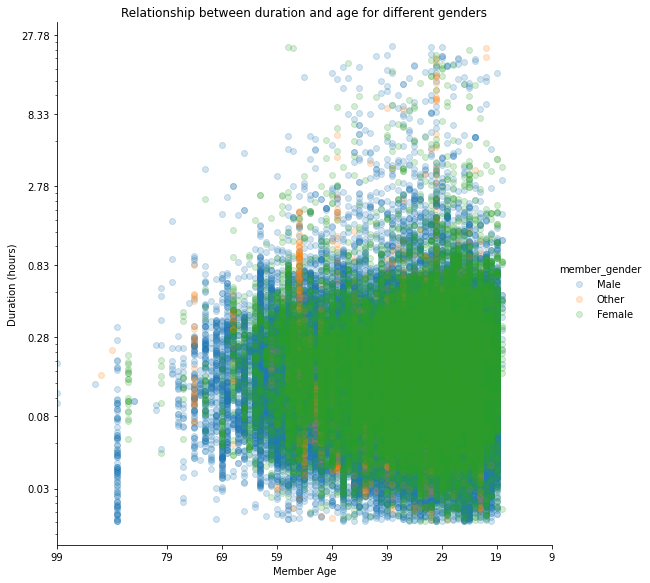

```python
g = sb.FacetGrid(data = fbike_clean[fbike_clean.distance<60], hue = 'member_gender', height = 8);
g.map(plt.scatter, 'member_birth_year', 'duration_sec', alpha=0.2);
plt.yscale('log');
g.add_legend();

# change tick labels for age
ticks=[1920, 1940, 1950, 1960, 1970, 1980, 1990, 2000, 2010];
labels = ['{}'.format(v) for v in 2019-np.array(ticks)];
plt.xticks(ticks, labels) # relabel the x axis with ages in stead of birth year
plt.xlim([1920, 2010]); # excluding ages older than 100, whihc could be errors in dataset

# change tick labels for duration in hours
ticks=[100, 300, 1000, 3000, 10000, 30000, 100000];
labels = ['{:.2f}'.format(v) for v in np.array(ticks)/3600];
plt.yticks(ticks, labels);

plt.title('Relationship between duration and age for different genders');
plt.ylabel('Duration (hours)');
plt.xlabel('Member Age');
```

> The plot above shows the relationship between duration and age are similar for all genders, with male data points varying more than female data points.

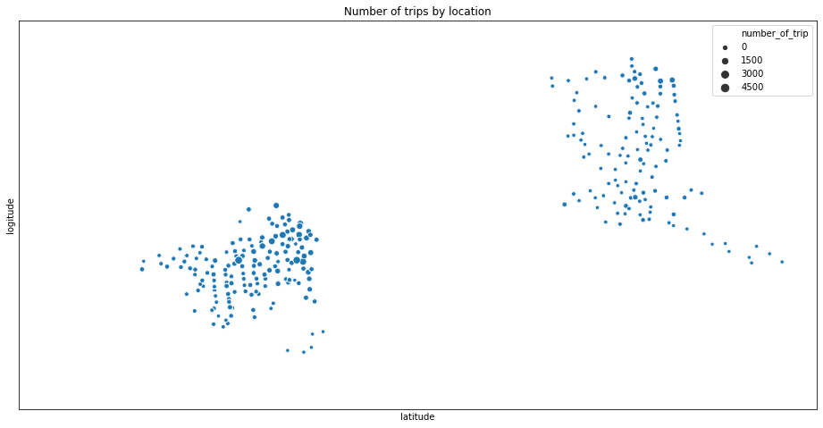

```python
# adding a new column of number of trips
num_of_trip = fbike_clean['start_station_id'].value_counts();
num_of_trip1 = num_of_trip.to_dict();
fbike_clean['number_of_trip']=fbike_clean['start_station_id'].map(num_of_trip1);

#plot number of trips by location
plt.figure(figsize=[16,8]);
sb.scatterplot(data=fbike_clean, x='start_station_longitude', y='start_station_latitude', size='number_of_trip');
plt.ylim([37.7,37.9]);
plt.xlim([-122.5,-122.2]);
plt.xticks([]);
plt.yticks([]);
plt.xlabel('latitude');
plt.ylabel('logitude');
plt.title('Number of trips by location');
```

The number of trips by location map above shows that there are more trips happening in the west bay area, whihc is more populated comapred tot the east bay area.

### Talk about some of the relationships you observed in this part of the investigation. Were there features that strengthened each other in terms of looking at your feature(s) of interest?

> I plotted duration as a function of member age. It shows similar trend for all genders that younger people travel longer duration than older people.

### Were there any interesting or surprising interactions between features?

> It is interesting to note that for a same age group, the duration can very a lot. This variation becomes larger for younger people.